2105623 · Lab 11 · **recorded run** of `lab11_collocation.ipynb`: every cell was run from a fresh Python 3.12 runtime on 18 November 2026; the first cell shows the versions. Use it if Google Colab will not open for you: the numbers match the ones the lab page checks. To run it yourself, go back to the lab page, choose Open in Colab, then Run all.

# Lab 11, Part B: collocation and Ipopt for a batch reactor

2105623 Optimization of Chemical Processes, Session 11 (draft for 2027)

## How to run this notebook in Colab

1. If Colab asks you to sign in, use any Google account (top right, **Sign in**).
2. Open the menu **Runtime → Run all** (Ctrl+F9; on a Mac ⌘+F9).
3. Colab shows *"Warning: This notebook was not authored by Google"*. This notebook comes from the course repository on GitHub (`soorathep/course-2105623`). Press **Run anyway**.
4. Wait. Step 1 installs CasADi, which contains the Ipopt solver; it takes about a minute. While a cell runs, a spinning circle shows at its left; when it finishes, its output appears below it.
5. Scroll down through Steps 2 to 6 and copy the numbers that the lab page asks for.
6. To try a change, edit a cell and press **Shift+Enter** to run that cell only. Cells use results from the cells above them, so keep them in order.
7. If you see an error, choose **Runtime → Restart session**, then **Runtime → Run all** again.

Nothing you change is saved unless you choose **File → Save a copy in Drive**. If Colab asks for permission to access your Google Drive, you can cancel: this notebook does not need it. Colab disconnects a session that has been idle for a while; if that happens, press **Run all** again.

*In your own Python instead of Colab:* `pip install casadi numpy scipy matplotlib`, download this notebook from the lab page, and run the cells in Jupyter.

**The problem** (Logsdon and Biegler, 1989): A → B → C in a batch reactor, dx₁/dt = −k₁x₁², dx₂/dt = k₁x₁² − k₂x₂, k₁ = 4000 exp(−2500/T), k₂ = 620,000 exp(−5000/T) in 1/h, x(0) = (1, 0), 298 ≤ T(t) ≤ 398 K. Choose T(t) to maximize x₂ at t = 1 h.

## Step 1. Install CasADi (it contains Ipopt)

Colab may print *"you may need to restart the kernel to use updated packages"*. You do not need to: CasADi was not loaded before this cell.

```python
%pip install -q casadi
import sys, casadi, numpy, scipy
print("Python", sys.version.split()[0], "| CasADi", casadi.__version__, "| NumPy", numpy.__version__, "| SciPy", scipy.__version__)
```

```
Python 3.12.3 | CasADi 3.8.2 | NumPy 2.5.5 | SciPy 1.18.1
```

## Step 2. Write the model file

This cell saves the course module `dyn_lab.py` (the same file as on the lab page) next to the notebook. `br_colloc(NE, K)` builds the collocation NLP in CasADi: NE finite elements, K Radau points in each, the temperature constant on each element (in units of 100 K), and calls Ipopt. `br_shoot(N)` is the single-shooting method of Part A, with SciPy's SLSQP.

```python
%%writefile dyn_lab.py
"""2105623 Session 11: dynamic optimization and model predictive control (2027 draft).

Part A  Batch reactor A -> B -> C, temperature profile that maximizes B at t = 1 h (Logsdon and Biegler, 1989):
        isothermal operation, single shooting with a piecewise-constant temperature, and (in Colab, with CasADi)
        orthogonal collocation solved by Ipopt
Part B  Collocation by hand: Radau collocation on dx/dt = -k x, and the sparsity of the collocation NLP
Part C  Level control of two tanks in series by MPC, solved at every step as a bounded least-squares problem

Runs in desktop Python and in the browser (NumPy and SciPy). Collocation with Ipopt needs CasADi: pip install casadi.
Course notation: lambda and mu are multipliers; the barrier parameter of Session 9 was tau.
"""
import json, math, sys
import numpy as np
from scipy.linalg import expm
from scipy.optimize import minimize, minimize_scalar, lsq_linear


def r6(v):
    if isinstance(v, (list, tuple, np.ndarray)):
        return [r6(u) for u in v]
    v = round(float(v), 6)
    return 0.0 if v == 0 else v


def sig(v, d=4):
    return f"{float(v):.{d}g}"


# ---------------------------------------------------------------------------
# Part A. Batch reactor: dx1/dt = -k1 x1^2, dx2/dt = k1 x1^2 - k2 x2, x(0) = (1, 0), 0 <= t <= 1 h,
#         k1 = 4000 exp(-2500/T), k2 = 620000 exp(-5000/T) (1/h), 298 <= T <= 398 K; maximize x2(1)
# ---------------------------------------------------------------------------
BR = {"tf": 1.0, "h": 0.005, "Tlo": 298.0, "Thi": 398.0, "k10": 4000.0, "E1": 2500.0, "k20": 620000.0, "E2": 5000.0}


def br_rates(T, k2f=1.0):
    return BR["k10"] * math.exp(-BR["E1"] / T), k2f * BR["k20"] * math.exp(-BR["E2"] / T)


def br_sim(Ts, x0=(1.0, 0.0), k2f=1.0, t_int=None, traj=False):
    """Integrate with the temperature Ts[i] held on interval i (piecewise constant) by classical RK4 with a fixed step
    of 0.005 h. Each interval lasts tf/len(Ts) unless t_int is given. Returns x at the end, or (t, x1, x2) if traj."""
    t_int = BR["tf"] / len(Ts) if t_int is None else t_int
    n = int(round(t_int / BR["h"])); h = t_int / n
    a, b = float(x0[0]), float(x0[1]); t = 0.0; out = [(t, a, b)]
    for T in Ts:
        k1, k2 = br_rates(float(T), k2f)
        for _ in range(n):
            f1a = -k1 * a * a; f1b = k1 * a * a - k2 * b
            a2 = a + h / 2 * f1a; b2 = b + h / 2 * f1b; f2a = -k1 * a2 * a2; f2b = k1 * a2 * a2 - k2 * b2
            a3 = a + h / 2 * f2a; b3 = b + h / 2 * f2b; f3a = -k1 * a3 * a3; f3b = k1 * a3 * a3 - k2 * b3
            a4 = a + h * f3a; b4 = b + h * f3b; f4a = -k1 * a4 * a4; f4b = k1 * a4 * a4 - k2 * b4
            a += h / 6 * (f1a + 2 * f2a + 2 * f3a + f4a); b += h / 6 * (f1b + 2 * f2b + 2 * f3b + f4b); t += h
            if traj:
                out.append((t, a, b))
    if traj:
        return [list(c) for c in zip(*out)]
    return [a, b]


def br_iso():
    """Isothermal operation: x2(1) against a constant T, and the best constant T."""
    Ts = np.arange(298.0, 398.01, 2.0)
    r = minimize_scalar(lambda T: -br_sim([T])[1], bounds=(BR["Tlo"], BR["Thi"]), method="bounded", options={"xatol": 1e-6})
    return {"T": Ts.tolist(), "x2": [br_sim([T])[1] for T in Ts], "Tbest": float(r.x), "x2best": float(-r.fun)}


def br_shoot(N, k2f=1.0, x0=(1.0, 0.0), t_int=None, u0=None):
    """Single shooting: N piecewise-constant temperatures, T = 298 + 100 u with 0 <= u <= 1, maximize x2(tf) by SLSQP
    with finite-difference gradients. Each objective evaluation integrates the model over the whole horizon."""
    u0 = np.full(N, 0.5) if u0 is None else np.asarray(u0, float)
    r = minimize(lambda u: -br_sim(298 + 100 * u, x0, k2f, t_int)[1], u0, method="SLSQP", bounds=[(0, 1)] * N,
                 options={"ftol": 1e-12, "maxiter": 300})
    return {"N": N, "T": (298 + 100 * r.x).tolist(), "x2": float(-r.fun), "nit": int(r.nit), "nfev": int(r.nfev), "status": int(r.status)}


def br_robust():
    """The nominal 20-interval profile when k2 is really 10% higher: predicted, obtained, best possible, and a
    shrinking-horizon re-optimization that uses the measured state but keeps the nominal (wrong) k2."""
    nom = br_shoot(20); tru = br_shoot(20, k2f=1.1)
    applied = br_sim(nom["T"], k2f=1.1)[1]
    x = [1.0, 0.0]; used = []; u_prev = (np.array(nom["T"]) - 298) / 100
    for i in range(20):
        T = nom["T"][0] if i == 0 else br_shoot(20 - i, x0=x, t_int=0.05, u0=u_prev[i:])["T"][0]
        used.append(T); x = br_sim([T], x0=x, k2f=1.1, t_int=0.05)
    return {"predicted": nom["x2"], "applied": applied, "best": tru["x2"], "T_best": tru["T"], "shrinking": x[1], "T_shrinking": used}


def br_colloc(NE=50, K=3, Thi=398.0, k2f=1.0, print_level=0):
    """Direct collocation: NE finite elements, K Radau points each, T constant on each element; Ipopt through CasADi.
    Variables: element-start states, collocation-point states and one temperature per element (in 100 K)."""
    import casadi as ca
    tau, Cm, Dv = colloc_matrices(K)
    h = BR["tf"] / NE; opti = ca.Opti(); Xk = opti.variable(2); opti.subject_to(Xk == ca.DM([1, 0])); us = []
    for e in range(NE):
        u = opti.variable(); opti.subject_to(opti.bounded(BR["Tlo"] / 100, u, Thi / 100)); opti.set_initial(u, 3.5); us.append(u)
        k1 = BR["k10"] * ca.exp(-BR["E1"] / (100 * u)); k2 = k2f * BR["k20"] * ca.exp(-BR["E2"] / (100 * u))
        Xc = [opti.variable(2) for _ in range(K)]
        for xc in Xc:
            opti.set_initial(xc, [0.5, 0.3])
        Xend = Dv[0] * Xk
        for j in range(1, K + 1):
            xp = Cm[0][j] * Xk
            for r in range(K):
                xp = xp + Cm[r + 1][j] * Xc[r]
            x = Xc[j - 1]
            opti.subject_to(xp == h * ca.vertcat(-k1 * x[0]**2, k1 * x[0]**2 - k2 * x[1]))
            Xend = Xend + Dv[j] * Xc[j - 1]
        Xk = opti.variable(2); opti.set_initial(Xk, [0.5, 0.3]); opti.subject_to(Xk == Xend)
    opti.minimize(-Xk[1])
    opti.solver("ipopt", {"print_time": False}, {"print_level": print_level, "tol": 1e-10, "sb": "yes"})
    s = opti.solve(); st = s.stats()
    return {"NE": NE, "K": K, "x2": float(s.value(Xk[1])), "iter": int(st["iter_count"]), "status": st["return_status"],
            "nvar": int(opti.nx), "ncon": int(opti.ng), "T": [100 * float(s.value(u)) for u in us]}
```

```python
# ---------------------------------------------------------------------------
# Part B. Collocation by hand
# ---------------------------------------------------------------------------
RADAU = {1: [1.0], 2: [1 / 3, 1.0], 3: [(4 - math.sqrt(6)) / 10, (4 + math.sqrt(6)) / 10, 1.0]}


def colloc_matrices(K):
    """Lagrange polynomials through tau = (0, Radau points): C[r][j] = derivative of polynomial r at point j,
    D[r] = polynomial r at tau = 1 (the end of the element)."""
    tau = [0.0] + RADAU[K]; Cm = [[0.0] * (K + 1) for _ in range(K + 1)]; Dv = [0.0] * (K + 1)
    for j in range(K + 1):
        p = np.poly1d([1.0])
        for r in range(K + 1):
            if r != j:
                p = p * np.poly1d([1.0, -tau[r]]) / (tau[j] - tau[r])
        Dv[j] = float(p(1.0)); dp = np.polyder(p)
        for r in range(K + 1):
            Cm[j][r] = float(dp(tau[r]))
    return tau, Cm, Dv


def colloc_decay(k=5.0, K=3, NE=4):
    """Radau collocation of dx/dt = -k x, x(0) = 1 on [0, 1]: returns the element-end values and the error at t = 1."""
    tau, Cm, Dv = colloc_matrices(K); h = 1.0 / NE; x = 1.0; ends = [1.0]; pts = []
    for e in range(NE):
        A = np.array([[Cm[r + 1][j] + (k * h if r + 1 == j else 0.0) for r in range(K)] for j in range(1, K + 1)])
        b = np.array([-Cm[0][j] * x for j in range(1, K + 1)]); xc = np.linalg.solve(A, b)
        pts += [((e + tau[j + 1]) * h, float(xc[j])) for j in range(K)]
        x = Dv[0] * x + sum(Dv[j + 1] * xc[j] for j in range(K)); ends.append(float(x))
    return {"K": K, "NE": NE, "ends": ends, "points": pts, "x1": x, "err": abs(x - math.exp(-k))}


def colloc_pattern(NE=4, K=3):
    """Sparsity of the equality-row Jacobian of the batch collocation NLP. Variables, element by element:
    [X_e (2), Xc_e,1..K (2K), u_e (1)], then the final state. Rows: 2K collocation rows and 2 continuity rows per
    element (the fixed initial state and the bounds on u are left out). Returns the nonzero (row, column) pairs."""
    tau, Cm, Dv = colloc_matrices(K); nv_e = 2 + 2 * K + 1; nz = []; row = 0
    for e in range(NE):
        c0 = e * nv_e; xc = lambda r, s: c0 + 2 + 2 * r + s
        for j in range(K):
            for s in range(2):
                cols = [c0 + s] + [xc(r, s) for r in range(K)] + [xc(j, 0), c0 + 2 + 2 * K] + ([xc(j, 1)] if s == 1 else [])
                nz += [(row, c) for c in sorted(set(cols))]; row += 1
        for s in range(2):
            cols = ([c0 + s] if abs(Dv[0]) > 1e-12 else []) + [xc(r, s) for r in range(K) if abs(Dv[r + 1]) > 1e-12] + [c0 + nv_e + s]
            nz += [(row, c) for c in sorted(set(cols))]; row += 1
    return {"NE": NE, "K": K, "rows": row, "cols": NE * nv_e + 2, "nz": nz, "density": len(nz) / (row * (NE * nv_e + 2))}


# ---------------------------------------------------------------------------
# Part C. Two tanks in series; MPC on the level of tank 2
#   A1 dh1/dt = u - h1/R1,  A2 dh2/dt = h1/R1 - h2/R2 + d;  u: valve flow 0 to 0.5 m3/min; d: unmeasured flow into tank 2
# ---------------------------------------------------------------------------
TANK = {"A1": 1.0, "A2": 1.0, "R1": 2.0, "R2": 4.0, "dt": 0.5, "umax": 0.5, "steps": 120, "x0": [0.6, 1.2], "u0": 0.3,
        "r0": 1.2, "r1": 1.6, "k_r": 10, "d1": -0.05, "k_d": 60}


def tank_model():
    """Exact discretization with the inputs held over each 0.5 min step (zero-order hold)."""
    A1, A2, R1, R2 = TANK["A1"], TANK["A2"], TANK["R1"], TANK["R2"]
    Ac = np.array([[-1 / (A1 * R1), 0], [1 / (A2 * R1), -1 / (A2 * R2)]]); Bc = np.array([[1 / A1, 0], [0, 1 / A2]])
    M = expm(np.block([[Ac, Bc], [np.zeros((2, 4))]]) * TANK["dt"])
    return M[:2, :2], M[:2, 2], M[:2, 3]


def tank_pred(N):
    """Level of tank 2 over the next N steps: y = Phi x + G U + Gd d."""
    Ad, Bd, Ed = tank_model(); P = [np.linalg.matrix_power(Ad, k) for k in range(N + 1)]
    Phi = np.array([P[i + 1][1] for i in range(N)]); G = np.zeros((N, N)); Gd = np.zeros(N)
    for i in range(N):
        for j in range(i + 1):
            G[i, j] = (P[i - j] @ Bd)[1]
        Gd[i] = sum((P[i - j] @ Ed)[1] for j in range(i + 1))
    return Phi, G, Gd


def mpc_solve(x, u_prev, r, dhat, N, w, P=None):
    """min sum (y_i - r_i)^2 + w sum (u_i - u_{i-1})^2 subject to 0 <= u_i <= umax: a bounded linear least-squares
    problem in U, solved by lsq_linear (bounded-variable least squares)."""
    Phi, G, Gd = tank_pred(N) if P is None else P
    D = np.eye(N) - np.eye(N, k=-1); e = np.zeros(N); e[0] = u_prev
    A = np.vstack([G, math.sqrt(w) * D]); b = np.concatenate([np.asarray(r) - Phi @ x - Gd * dhat, math.sqrt(w) * e])
    return lsq_linear(A, b, bounds=(0, TANK["umax"]), method="bvls").x


def tank_run(N=20, w=1.0, est=True, openloop=False):
    """Closed loop for 60 min: setpoint 1.2 -> 1.6 m at 5 min; an unmeasured withdrawal of 0.05 m3/min from tank 2
    starts at 30 min. est: update a constant-disturbance estimate from the one-step prediction error of h2.
    openloop: plan the whole hour at t = 0 and apply it without feedback."""
    Ad, Bd, Ed = tank_model(); P = tank_pred(N); S = TANK["steps"]
    rr = lambda k: TANK["r0"] if k < TANK["k_r"] else TANK["r1"]
    x = np.array(TANK["x0"]); u = TANK["u0"]; dh = 0.0; H1 = [x[0]]; H2 = [x[1]]; U = []; Dh = []
    plan = mpc_solve(x, u, [rr(i + 1) for i in range(S)], 0.0, S, w) if openloop else None
    for k in range(S):
        if openloop:
            u = plan[k]
        else:
            u = mpc_solve(x, u, [rr(k + i + 1) for i in range(N)], dh, N, w, P)[0]
        d = TANK["d1"] if k >= TANK["k_d"] else 0.0
        xp = Ad @ x + Bd * u + Ed * dh; x = Ad @ x + Bd * u + Ed * d
        if est and not openloop:
            dh = dh + (x[1] - xp[1]) / Ed[1]
        H1.append(x[0]); H2.append(x[1]); U.append(u); Dh.append(dh)
    H2 = np.array(H2); seg = H2[TANK["k_r"]:TANK["k_d"]]; step = TANK["r1"] - TANK["r0"]
    out = np.where(np.abs(seg - TANK["r1"]) > 0.02 * step)[0]
    after = H2[TANK["k_d"]:]
    return {"N": N, "w": w, "est": est, "openloop": openloop, "h1": r6(H1), "h2": r6(H2), "u": r6(U), "dhat": r6(Dh),
            "overshoot": float(max(0.0, (seg.max() - TANK["r1"]) / step * 100)), "settle": float((out[-1] + 1 - 0) * TANK["dt"]) if len(out) else 0.0,
            "dist_dev": float(np.max(np.abs(after - TANK["r1"]))), "offset": float(H2[-1] - TANK["r1"]),
            "sat": int(np.sum(np.array(U) > TANK["umax"] - 1e-6))}
```

```python
def tank_grid():
    return [tank_run(N, w) for N in (5, 10, 20, 40) for w in (0.01, 0.1, 1.0, 10.0)]


def clean(o):
    if isinstance(o, dict):
        return {k: clean(v) for k, v in o.items()}
    if isinstance(o, (list, tuple)):
        return [clean(v) for v in o]
    if isinstance(o, np.ndarray):
        return clean(o.tolist())
    if isinstance(o, (float, np.floating)):
        return float(o) if np.isfinite(o) else None
    if isinstance(o, (np.integer,)):
        return int(o)
    if isinstance(o, np.bool_):
        return bool(o)
    return o


def lab_results():
    iso = br_iso(); shoot = {N: br_shoot(N) for N in (1, 2, 4, 5, 10, 20)}
    tr = {N: br_sim(shoot[N]["T"], traj=True) for N in (1, 20)}
    return {"br": BR, "iso": iso, "shoot": {str(k): v for k, v in shoot.items()}, "traj": {str(k): v for k, v in tr.items()},
            "robust": br_robust(), "tank": TANK, "mpc_grid": tank_grid(), "mpc_noest": tank_run(20, 1.0, est=False), "mpc_open": tank_run(20, 1.0, openloop=True)}


def colloc_results():
    """Collocation runs for the slides and the lab (CasADi); None where CasADi is not installed (the browser)."""
    try:
        import casadi
    except ImportError:
        return None
    runs = {str(n): br_colloc(n) for n in (10, 25, 50, 100)}
    return {"casadi": casadi.__version__, "runs": runs, "Tmax370": br_colloc(50, Thi=370.0), "k2f11": br_colloc(50, k2f=1.1), "log": br_colloc_log()}


def br_colloc_log():
    """Ipopt's printed log for the 50-element collocation run (Lab 11, notebook Step 3), without the banner."""
    import os, subprocess
    here = os.path.dirname(os.path.abspath(__file__))
    r = subprocess.run([sys.executable, "-c", "import dyn_lab as m; m.br_colloc(50, 3, print_level=5)"], cwd=here, capture_output=True, text=True)
    lines = r.stdout.splitlines()
    start = next((i for i, l in enumerate(lines) if l.startswith("This is Ipopt")), 0)
    return "\n".join(lines[start:]).strip()


def classroom_results():
    import scipy
    R = {"meta": {"numpy": np.__version__, "scipy": scipy.__version__, "python": sys.version.split()[0]}}
    R["lecture"] = {"decay": {f"{K}-{n}": colloc_decay(K=K, NE=n) for K in (1, 2, 3) for n in (1, 2, 4, 8, 16)},
                    "pattern": colloc_pattern(4, 3), "colloc": colloc_results(),
                    "mpc_first": mpc_solve([0.6, 1.2], 0.3, [1.6] * 20, 0.0, 20, 1.0).tolist()}
    R["lab"] = lab_results()
    return clean(R)


if __name__ == "__main__":
    if "--json" in sys.argv:
        R = classroom_results()
        with open("dyn-results.json", "w") as fh:
            json.dump(R, fh)
        print("wrote dyn-results.json", R["meta"]); sys.exit()
    iso = br_iso(); print("A iso", r6(iso["Tbest"]), r6(iso["x2best"]))
    for N in (1, 5, 20):
        s = br_shoot(N); print("A shoot", N, r6(s["x2"]), s["nit"], s["nfev"], r6(s["T"][:3]))
    rb = br_robust(); print("A robust", {k: r6(v) for k, v in rb.items() if not k.startswith("T")})
    for K in (1, 2, 3):
        print("B decay K", K, [sig(colloc_decay(K=K, NE=n)["err"], 3) for n in (1, 2, 4, 8, 16)])
    p = colloc_pattern(); print("B pattern", p["rows"], p["cols"], len(p["nz"]), r6(p["density"]))
    for q in (tank_run(20, 1.0, est=False), tank_run(20, 1.0), tank_run(20, 1.0, openloop=True), tank_run(5, 10.0)):
        print("C tank", q["N"], q["w"], q["est"], q["openloop"], r6(q["overshoot"]), q["settle"], r6(q["offset"]), r6(q["dist_dev"]), q["sat"])
```

```
Overwriting dyn_lab.py
```

```python
import dyn_lab as m
print("Bounds on T:", m.BR["Tlo"], "to", m.BR["Thi"], "K; final time", m.BR["tf"], "h")
```

```
Bounds on T: 298.0 to 398.0 K; final time 1.0 h
```

## Step 3. Collocation with 50 elements and its Ipopt log

Lab step 2a asks for x₂(1 h), the number of Ipopt iterations and the number of NLP variables. Ipopt minimizes −x₂(1 h), so the `objective` column ends near −0.6107. Read `inf_pr` (violation of the collocation and continuity rows) and `inf_du` (stationarity) together: both must fall to about 10⁻¹⁰. The `EXIT:` line is the status.

```python
r = m.br_colloc(50, 3, print_level=5)
print()
print("Status:", r["status"], "| iterations:", r["iter"], "| NLP variables:", r["nvar"], "| rows:", r["ncon"])
print("x2(1 h) =", round(r["x2"], 6))
```

```
This is Ipopt version 3.14.19, running with linear solver MUMPS 5.8.2.

Number of nonzeros in equality constraint Jacobian...:     1952
Number of nonzeros in inequality constraint Jacobian.:       50
Number of nonzeros in Lagrangian Hessian.............:      500

Total number of variables............................:      452
                     variables with only lower bounds:        0
                variables with lower and upper bounds:        0
                     variables with only upper bounds:        0
Total number of equality constraints.................:      402
Total number of inequality constraints...............:       50
        inequality constraints with only lower bounds:        0
   inequality constraints with lower and upper bounds:       50
        inequality constraints with only upper bounds:        0

iter    objective    inf_pr   inf_du lg(mu)  ||d||  lg(rg) alpha_du alpha_pr  ls
   0 -3.0000000e-01 2.09e+00 1.07e-02  -1.0 0.00e+00    -  0.00e+00 0.00e+00   0
   1 -5.4399896e-01 1.49e-02 5.57e-03  -1.0 1.00e+00    -  1.00e+00 1.00e+00h  1
   2 -5.8192105e-01 1.30e-04 2.43e-04  -2.5 3.79e-02    -  1.00e+00 1.00e+00h  1
   3 -6.1820994e-01 4.23e-04 9.27e-04  -3.8 1.18e-01    -  9.54e-01 1.00e+00h  1
   4 -6.1343375e-01 4.51e-03 7.82e-03  -5.7 5.82e-01    -  4.94e-01 7.51e-01H  1
   5 -6.1113104e-01 3.19e-05 2.19e-03  -5.7 3.64e-02    -  3.25e-01 1.00e+00h  1
   6 -6.1070526e-01 3.30e-05 8.28e-04  -5.7 1.10e-01    -  9.74e-01 1.00e+00H  1
   7 -6.1070971e-01 1.43e-05 7.77e-06  -5.7 1.17e-02    -  1.00e+00 1.00e+00h  1
   8 -6.1070870e-01 3.97e-06 2.34e-06  -8.6 6.19e-03    -  9.95e-01 1.00e+00h  1
   9 -6.1070835e-01 1.09e-08 6.49e-09  -8.6 3.25e-04    -  1.00e+00 1.00e+00h  1
iter    objective    inf_pr   inf_du lg(mu)  ||d||  lg(rg) alpha_du alpha_pr  ls
  10 -6.1070835e-01 7.59e-13 4.54e-13 -11.0 2.71e-06    -  1.00e+00 1.00e+00h  1

Number of Iterations....: 10

                                   (scaled)                 (unscaled)
Objective...............:  -6.1070835396955148e-01   -6.1070835396955148e-01
Dual infeasibility......:   4.5420933244744865e-13    4.5420933244744865e-13
Constraint violation....:   7.5868478166540854e-13    7.5868478166540854e-13
Variable bound violation:   0.0000000000000000e+00    0.0000000000000000e+00
Complementarity.........:   9.2417495256002435e-12    9.2417495256002435e-12
Overall NLP error.......:   9.2417495256002435e-12    9.2417495256002435e-12


Number of objective function evaluations             = 13
Number of objective gradient evaluations             = 11
Number of equality constraint evaluations            = 13
Number of inequality constraint evaluations          = 13
Number of equality constraint Jacobian evaluations   = 11
Number of inequality constraint Jacobian evaluations = 11
Number of Lagrangian Hessian evaluations             = 10
Total seconds in IPOPT                               = 0.023

EXIT: Optimal Solution Found.

Status: Solve_Succeeded | iterations: 10 | NLP variables: 452 | rows: 452
x2(1 h) = 0.610708
```

## Step 4. Refine the elements, and compare with single shooting

Lab step 2b. The table refines the collocation from 10 to 100 elements and lists single shooting with 10 and 20 intervals (these take a few seconds each). Compare collocation with 10 elements and shooting with 10 intervals: the same control discretization solved in two different ways.

```python
print(f"{'method':30s} {'x2(1 h)':>9s} {'iterations':>10s}")
for NE in (10, 25, 50, 100):
    q = m.br_colloc(NE, 3)
    print(f"{'collocation, ' + str(NE) + ' elements':30s} {q['x2']:9.6f} {q['iter']:10d}")
for N in (10, 20):
    s = m.br_shoot(N)
    print(f"{'single shooting, ' + str(N) + ' intervals':30s} {s['x2']:9.6f} {s['nit']:10d}")
```

```
method                           x2(1 h) iterations
collocation, 10 elements        0.610070          8
```

```
collocation, 25 elements        0.610536          9
```

```
collocation, 50 elements        0.610708         10
```

```
collocation, 100 elements       0.610792         10
single shooting, 10 intervals   0.610070         24
single shooting, 20 intervals   0.610454         32
```

## Step 5. The best profile

The temperature profile (one value per element) and the state trajectories, simulated again with the integrator of Part A as an independent check of the collocation answer.

```
x2(1 h): collocation 0.610792 | RK4 simulation of the same profile 0.610792
```

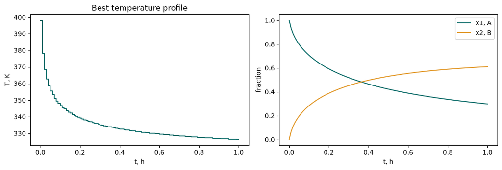

```python
import matplotlib.pyplot as plt
r = m.br_colloc(100, 3)
t, x1, x2 = m.br_sim(r["T"], traj=True)
print("x2(1 h): collocation", round(r["x2"], 6), "| RK4 simulation of the same profile", round(x2[-1], 6))
fig, ax = plt.subplots(1, 2, figsize=(11, 3.8))
NE = len(r["T"])
ax[0].step([i / NE for i in range(NE + 1)], r["T"] + [r["T"][-1]], where="post", color="#0F6E6B")
ax[0].set_xlabel("t, h"); ax[0].set_ylabel("T, K"); ax[0].set_title("Best temperature profile")
ax[1].plot(t, x1, color="#0F6E6B", label="x1, A"); ax[1].plot(t, x2, color="#E29A2D", label="x2, B")
ax[1].set_xlabel("t, h"); ax[1].set_ylabel("fraction"); ax[1].legend(); plt.tight_layout(); plt.show()
```

## Step 6 (optional). Change one condition

Try a tighter upper limit on the temperature (`Thi`), fewer collocation points per element (`K = 1` is implicit Euler), or a different `k2f` (the factor on k₂; Part D of the lab uses 1.1). Change a number and press Shift+Enter.

```python
q = m.br_colloc(50, 3, Thi=370.0)       # try Thi, K = 1, or k2f = 1.1
print(q["status"], "| iterations:", q["iter"], "| x2(1 h):", round(q["x2"], 6), "| first T:", round(q["T"][0], 1), "K")
```

```
Solve_Succeeded | iterations: 14 | x2(1 h): 0.610487 | first T: 370.0 K
```

## If something goes wrong

| What you see | What to do |
| --- | --- |
| `ModuleNotFoundError: No module named 'casadi'` | Step 1 did not finish. Run it again; if Colab offers **Restart session**, accept, then **Runtime → Run all**. |
| `NameError: name 'm' is not defined` | A cell ran before Step 2. Use **Runtime → Run all**. |
| The top right says **Reconnect** | The session was disconnected. Press **Reconnect**, then **Runtime → Run all**. |
| The install in Step 1 fails or hangs | **Runtime → Disconnect and delete runtime**, then **Run all**. If it still fails, use the recorded run on the lab page. |
| Ipopt ends with `Restoration_Failed` or `Maximum_Iterations_Exceeded` after you changed a setting | Go back to the values in the cell, or start from a closer guess; Step 3's settings converge in about 10 iterations. |